# 도심 침수 예측 — 전처리 재설계 진행 보고서

작성일 2026-06-23 · 작업 디렉토리 `/home/namjun/city_flood` · 강우 데이터 통합 진행 중

**한 줄 요약.** 서울시 도로노면·하수관로 수위 센서로 침수를 예측하려 했으나, 데이터 품질 조사에서 **침수 **양성을 만드는 센서의 ~93%가 아티팩트형**(비영값 고착·사각파·겨울지배; 마른 도로 0 지배는 정상)**임이 드러나 전처리를 재설계했다. 재설계 위에서 검증한 결과 **① 도로↔하수 결합은 약하고 ② 단순 persistence가 강한 베이스라인**이며, **③ 진짜 개선은 라벨 정제 + 강우 확보**에서 온다는 결론에 도달했다. 현재 KMA AWS 강우(1분)를 통합 중이다.

## 0. 배경과 재설계 이유

당초 목표는 하수관로 수위로 도로 침수를 최대 180분 전 예측하는 이종 그래프(GNN) 모델이었다. 그러나 EDA에서 근본 문제가 드러났다:

- **라벨 오염** — 도로 `flood_flag=level>0`의 가짜 양성 대부분이 **비영값 고착 센서**에서 나옴(마른 1월에도 침수율이 여름과 맞먹음=물리적 불가). ⚠️마른 도로가 0인 것은 정상 — 문제는 0이 아닌 값에 눌어붙은 센서가 가짜 양성을 만든 것.
- **센서 특성** — 도로=이산 단계 게이지(0,1,2,…,96; 96=측정범위 saturation), 하수=연속 기저유량(95%>0, surcharge 드묾).
- **변환 자체는 정상** — 원본 CSV=parquet 정확. 문제는 **라벨 정의 + 센서 아티팩트**.

→ 모델링 전에 **시계열 전처리 재설계**(마스크 중심·차분 피처·stuck 구간 탐지·도메인 분리)로 방향 전환.

## 1. 도로 · 하수 상관 분석

"하수가 도로 침수를 선행하는가"를 정식 검증했다. 핵심은 **페어링을 추측이 아니라 실제 데이터로** 만든 것이다. 옛 거리추측 페어링을 폐기하고, **공식 GIS 좌표로 도로·하수 수위계가 같은 지점(동일위치, 중앙 ~44m)**인 쌍만 사용했다.

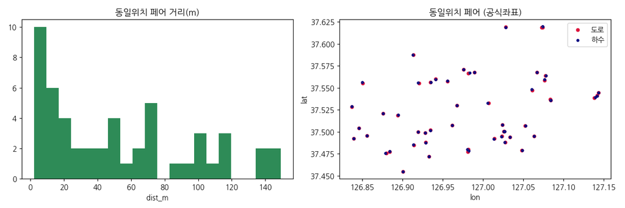

그림 1. 공식 GIS 기반 동일위치(co-located) 페어링. 좌: 페어 거리 분포(중앙 ~44m). 우: 도로(빨강)–하수(파랑) 동일지점 쌍. 옛 배수구역·거리추측 페어링은 전부 폐기.

동일위치 도로센서는 정제 후 침수 이벤트가 **0에 수렴**(이벤트 많은 센서는 stuck 오염). → 도로 라벨에 의존하지 않는 방법(차분 교차상관·하수 트리거 에폭)으로 검증.

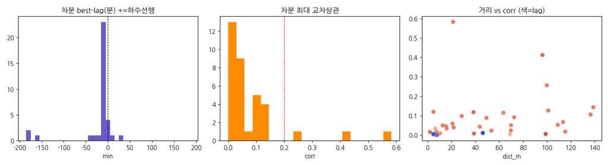

그림 2. 차분 교차상관 lead-lag. corr 중앙 ≈0.045(매우 약함), best-lag −1 지배 = 하수가 도로를 약 10분 후행. 선행 신호 미약.

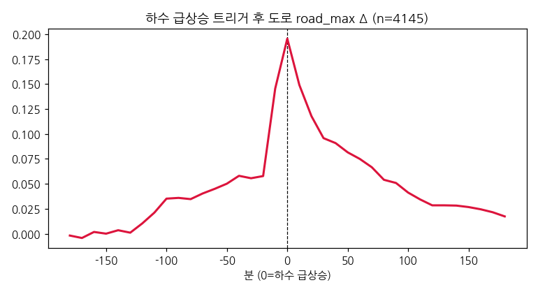

그림 3. 하수 급상승 트리거 에폭(도로 라벨 우회). 하수가 급상승한 시점 기준 도로 반응은 동시·미약(사후/사전 1.75배).

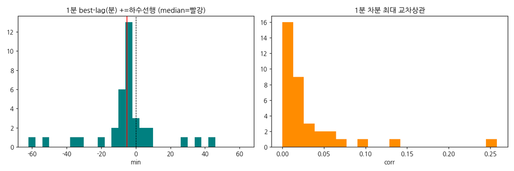

그림 4. 원본 1분 해상도 재검토. corr 중앙 0.015(1분에선 더 약함=노이즈), best-lag 중앙 −5분(하수 후행). 해상도·페어링 무관하게 '약함·하수 후행' 안정적.

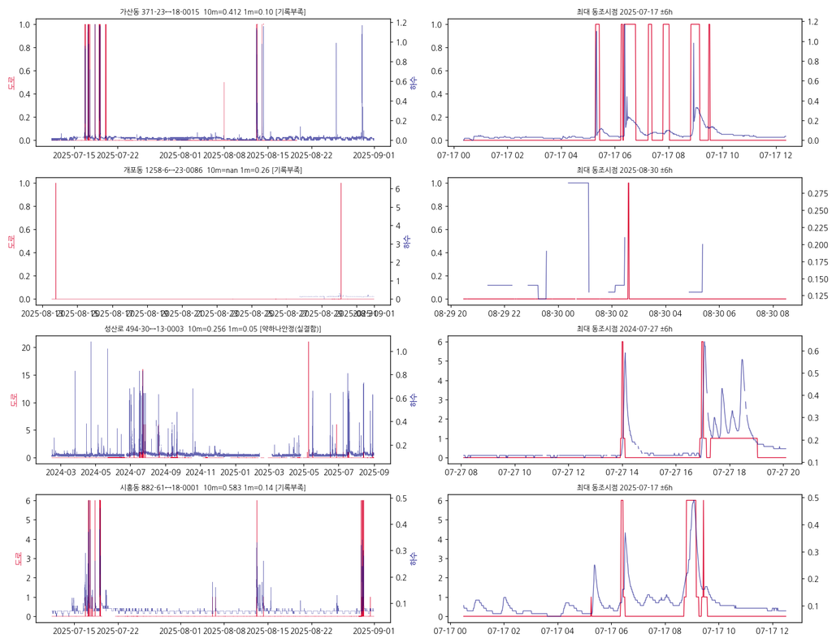

그림 5. 튄 강결합 페어(corr 0.2~0.58) 진위 검증. 시흥동·가산동은 기록 52일뿐+1분 급락+단일이벤트 제거 시 붕괴(허상). 성산로 494-30만 장기·안정(진짜지만 약함 ~0.05).

**결론.** 도로↔하수 결합은 약하고 하수가 약간 후행한다. 튄 강결합은 검증하면 **대부분 허상**. → **센서 간 예측 엣지에 의존하지 말 것.** (완전 무관 단정은 보류)

## 2. 단독 nowcast 베이스라인 (persistence 대비)

각 센서를 **자기이력만**으로(cross-엣지 없이) 예측하는 베이스라인. 10분 패널, H=+10/+30/+60분.

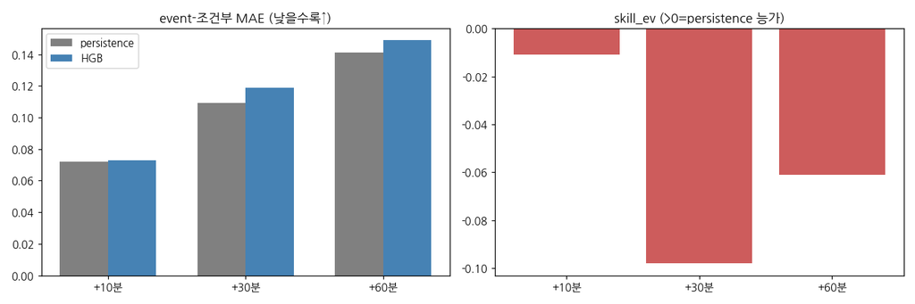

그림 6. 수위 회귀(road_max t+H). 자기이력 HGB의 skill이 음수~0 → persistence(naive-last)를 못 이김. road_max가 0/지속 지배.

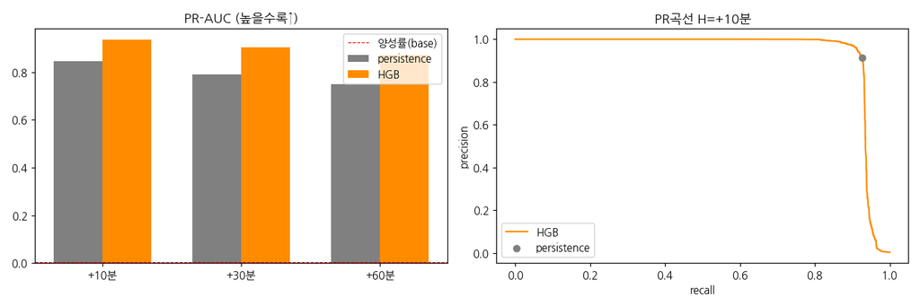

그림 7. 침수 분류(flood_t6 t+H). 모델 PR-AUC 0.94 vs persistence 0.85(@+10분) — 단 둘 다 오염으로 부풀려짐.

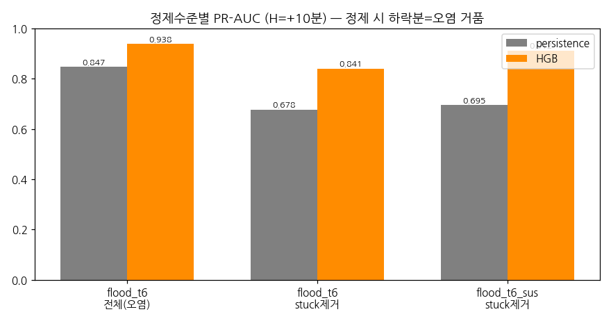

그림 8. 오염 거품 정량화. stuck 제거 시 persistence PR-AUC 0.847→0.678(−0.17≈20%가 거품). 현행 점수의 ~20%+가 stuck-지속 오염.

단독 nowcast에서 **persistence가 매우 강한 바**이고, 분류의 높은 점수는 상당 부분 **stuck 오염 거품**. 라벨 정제·강우 없이는 의미 있는 향상이 어렵다.

## 3. 라벨 신뢰도 향상 — 센서별 진위 감사

양성을 만드는 98개 센서를 시계열 구조(stuck·장기run·단일값·계절성·에피소드)로 진짜/아티팩트로 분류했다.

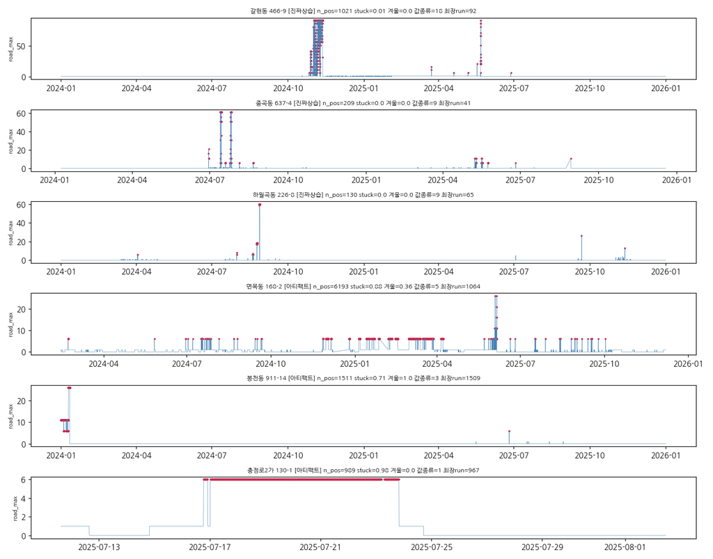

그림 9. 진짜 상습침수 vs 아티팩트. 진짜(상단)는 여름에 솟았다 0으로 회복하는 에피소드형·값 다양. 아티팩트(하단)는 사각파·고정값 블록·단일값.

| 판정 | 센서 수 | 양성 수 | 비율 |
| --- | --- | --- | --- |
| 아티팩트 | 55 | 22,147 | 93% |
| 애매 | 36 | 228 | 1% |
| 진짜상습 | 7(+승격3) | 1,500 | 6% |

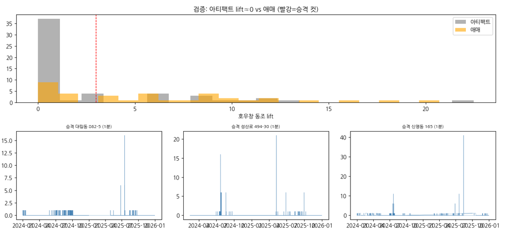

그림 10. 애매 센서 추가 판별(호우창 동조). 진짜상습 센서 침수시각 ±6h를 '호우창'으로 보고 동조도(lift) 측정. 검증: 아티팩트 lift≈0. 승격 3·강등 11·미결 22.

## 4. 강우 임시 검증 + 상습침수 지점 리포트

공공관측소 10분 강우(48개소, ~1.5km)로 신뢰 센서를 교차검증했다. **강우는 절대 기준이 아니다** (상수도 파열·하수 역류·하천 역류 등 비강우 침수 + 관측소 거리누락) — 강우 동반은 강한 양성, 무강우는 약한 음성으로 본다.

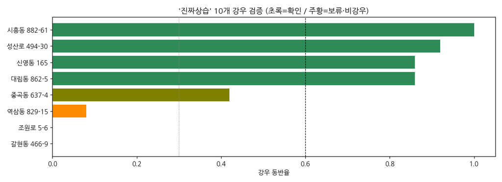

그림 11. '진짜상습' 10센서 강우 재검증. 시흥동(1.0)·성산로(0.92)·신영동·대림동은 강우확인. 갈현동 466-9(1021건·11월피크·강우 0%)는 휴리스틱이 놓친 의심 사례로 강등.

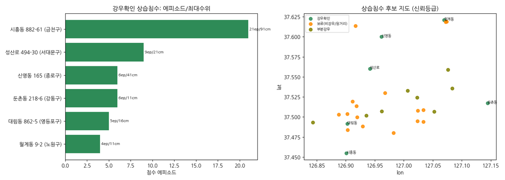

그림 12. 상습침수 후보 지도(신뢰등급). 좌: 강우확인 6지점 에피소드/최대수위. 우: 신뢰등급별 공간 분포.

**강우확인 상습침수 6지점**: 시흥동 882-61(금천)·성산로 494-30(서대문)·신영동 165(종로)·대림동 862-5(영등포)·둔촌동 218-6(강동)·월계동 9-2(노원). 모두 여름집중·강우동반 0.75~1.0.

**중요 교정.** 처음엔 무강우 센서를 '아티팩트'로 단정했으나(과함), 형태가 정상이면 비강우 실침수일 수 있어 **'보류(비강우/원거리)'**로 완화했다. 강우는 '확정 도구'가 아니라 **양성 확증·위험순위 도구**.

## 5. KMA AWS 강우 통합 (현재 진행 중)

더 정밀한 검증을 위해 기상청 API허브 **AWS 매분(1분) 자료**를 통합 중이다. 다운로더·피처빌더·좌표/매핑은 준비·검증 완료.

| 망 | 도로→최근접 강우 거리(중앙) |
| --- | --- |
| 공공 강우량계(47) | 1,468 m |
| AWS 서울(44) | 1,746 m (오히려 성김) |
| 공공 + AWS 결합(91) | 1,190 m (최선) |

서울 안에서 AWS는 공공보다 촘촘하지 않다. AWS의 실익은 **밀도가 아니라 1분 해상도·다변량·경기 인접 보강**. → **공공+AWS 결합**이 거리누락을 가장 줄인다.

현재 여름시즌(2024·2025 6/1~9/30) 다운로드 진행 중(재개 가능). 완료 후: 머지 → 10분 강우피처 → 공공+AWS 결합 매핑 → 강우통합 베이스라인.

## 6. 하수 surcharge(만관) 중심 전환 + 첫 검증 (2026-06-20)

**관점 전환.** 도로 노면 침수를 직접 예측하는 대신, **침수의 물리적 원인인 하수관 만관(surcharge)**에 주목한다. 침수는 하수관이 유량을 다 못 받아 **만관 → 맨홀 월류 → 도로 침수**로 이어지기 때문. 오염된 도로 라벨에 의존하지 않고, 연속·깨끗한 하수 데이터를 쓰며, 도로(강우확인 6지점)는 **타겟에서 검증 앵커로 강등**(폐기 아님).

**surcharge 정의**: `fill_rate = 수위 / 관 높이`. fill_rate ≥ 1 = 만관(관이 꽉 참=가압). 먼저 `관규격` 기반으로 capacity를 재정비(1200~1500m 같은 mm→m 단위 오류 119센서 교정)해 fill_rate를 신뢰 가능하게 했다.

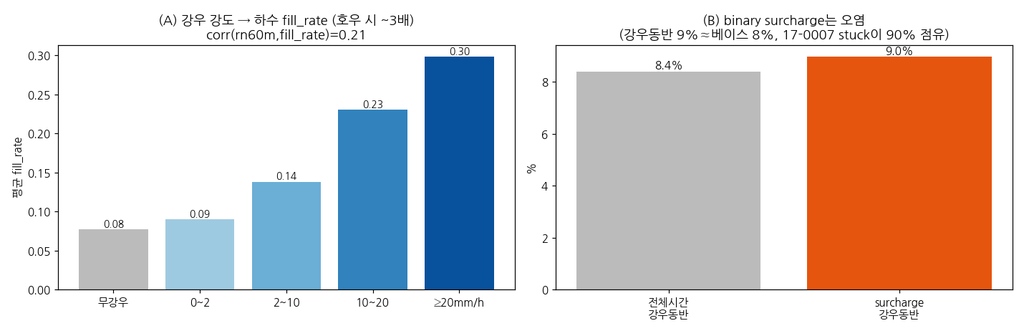

그림 13. AWS 1분 강우(2024 여름)로 본 강우→하수 관계. (A) 강우 강도가 셀수록 하수 fill_rate가 뚜렷이 상승(호우 시 ~3배, corr 0.21). (B) 그러나 binary surcharge 플래그는 stuck 센서(17-0007)가 90% 점유해 강우동반율이 베이스라인과 비슷 = 오염.

| 검증 | 결과 |
| --- | --- |
| (A) 강우 → 하수 fill_rate | ✅ 실재 (corr 0.21, 호우≥10mm/h 시 0.077→0.24 = 3배) |
| (B) binary `is_surcharge` | ❌ 오염 (90%가 3센서, 17-0007=5650건·강우동반 5%=stuck) |
| (C) 진짜 강우성 만관 | ✅ 존재 (호우≥20mm/h 시 18센서가 fill≥1 도달) |

**"비 오면 관이 찬다"(메커니즘 1단계)는 데이터로 확인됨** — 도로↔하수 결합(0.05)보다 훨씬 강한 0.21. 강우 통합의 효과가 바로 나타난 첫 사례.

**그러나** surcharge 플래그도 도로 라벨처럼 **stuck 아티팩트로 오염**되어 있다(17-0007 등). → **아티팩트 정제 + 강우조건부**로 봐야 진짜 만관 신호(18센서)가 드러난다.

### 인프라 정비 (오늘)

- KMA AWS 1분 강우 통합: 인증키(.env)·다운로더(행수캡 때문에 180분 창)·지점좌표(745) 확보. **강우창 타겟 모드**로 변경(비 온 창만 받아 콜 ~38%로 축소).
- 받은 데이터: **2024 여름 거의 전체**(2024-06-01~08-28). 일일 호출 한도로 일시 중단(재개 가능).
- ⚠️ 서울 AWS(44)는 공공 강우량계(47)보다 성김 → **공공+AWS 결합(1190m)**이 최선. AWS 이점은 1분 해상도·다변량.

### 다음 단계

- ① 하수 surcharge 센서 **진위 감사**(도로처럼): stuck(17-0007 등) 제외 → 강우성 만관 센서 확정.
- ② 진짜 만관 센서가 **도로 침수 지점(확정 6지점/co-located)과 시공간 동조**하는지 → *강우 → 만관 → 침수* 사슬 완성 검증.
- ③ 한도 리셋 후 나머지 여름 강우 다운로드(강우창 타겟).

## 7. 하수 surcharge 진위 감사 — 진짜 강우성 만관 센서 확정 (2026-06-24)

**가설 1단계 정밀 검증.** `is_surcharge` 플래그가 **진짜 강우성 만관**인지 **센서 아티팩트(stuck·capacity 오류)**인지 223개 surcharge 센서를 하나씩 가렸다. 도로 라벨 감사와 동일 철학.

**판정 핵심 = 강우 lift** = (surcharge 시점의 최근 6h 강우율) ÷ (평상시 강우율). lift≥2면 surcharge가 강우에 집중 = 진짜 강우성 만관. (nearest 공공강우, 2024-01~2025-08 구간만 검증 가능)

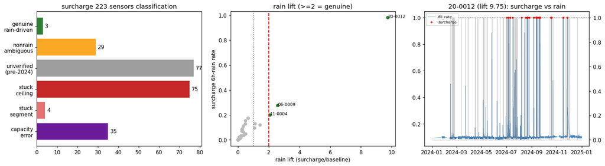

그림 14. 하수 surcharge 223센서 진위감사. (좌) 분류 — 진짜 강우성 만관은 3센서뿐, stuck(천장 75·구간 4)+capacity에러 35 = 114센서가 명백 아티팩트. (중) 강우 lift(평상시 대비 surcharge시 강우율) ≥2가 진짜: 20-0012(9.75)·06-0009(2.58)·11-0004(2.08). (우) 20-0012의 surcharge(빨강)가 여름 강우대(회색)에 정확히 몰림.

| 판정 | 센서 수 | 의미 |
| --- | --- | --- |
| **진짜 강우성 만관** | **3** | 20-0012(lift 9.75, 강우시 만관율 98%)·06-0009(2.58)·11-0004(2.08) |
| 비강우 모호 | 29 | 물리적 overshoot이나 공공강우 무동반 — AWS 재검증 대상 |
| 미검증 | 77 | surcharge가 2022년(강우 커버리지 밖) |
| stuck 천장 | 75 | fill이 정확히 1.0에 핀 = 천장 saturation 고착(17-0007·19-0005 등) |
| stuck 구간 | 4 | surcharge가 stuck 세그먼트 안 |
| capacity 에러 | 35 | fill 중앙값>1 = 관높이 과소설정(특히 22/23구역 다수) |

**binary `is_surcharge`는 도로 라벨처럼 아티팩트가 지배** — stuck(천장/구간 79)+capacity에러(35)=114센서가 명백 허위. 정제 후 진짜 강우성 만관은 **20-0012가 가장 강한 증거**(강우 시 만관율 98%, 평상시 10%).

**3은 하한이다.** 공공강우는 ~1.5km라 국지성 호우를 놓침 → '비강우 모호 29'·'미검증 77' 중 일부는 실제 강우성일 수 있다. **AWS 1분 강우(다운로드 중)로 재검증**하면 확정 센서가 늘어날 여지.

### capacity 재교정 — "capacity에러"의 정체 (2026-06-24)

진위감사에서 나온 **capacity에러 35센서가 '센서 불량'인지 확인**했더니, 답은 **측정 기준 불일치**였다. 관 안 물깊이는 관 높이를 넘을 수 없는데, 이 센서들은 **수위 중앙값이 관 높이를 초과**한다 = 그 '수위'는 관내 물깊이가 아니라 다른 기준(절대표고·설치오프셋)으로 측정된 값. 따라서 `fill_rate=수위/관높이`가 성립하지 않는다.

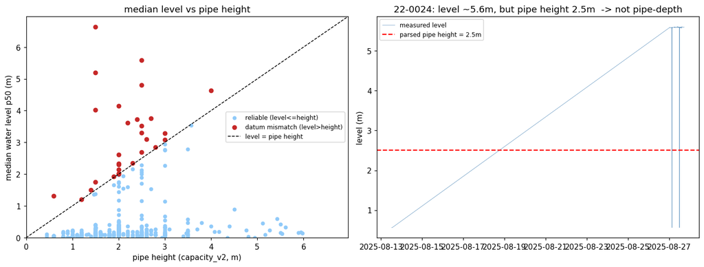

그림 15. capacity(관높이) 재교정. (좌) 점선=수위=관높이. 점선 위 빨강점 29센서는 '수위 중앙값 > 관높이'로 물리적으로 불가능 = 그 센서의 수위는 관내 물깊이가 아님(다른 기준). (우) 예: 22-0024는 관높이 2.5m인데 수위가 5.6m → fill_rate 무의미.

| capacity 판정 (485센서) | 수 |
| --- | --- |
| 신뢰 (수위 ≤ 관높이) | 455 |
| 기준 불일치 (수위 > 관높이, fill_rate 무의미) | 29 |
| capacity 미상 | 1 |

**중요 정정**: "아티팩트 114"는 과한 묶음이었다. capacity에러는 **센서 불량이 아니라 fill_rate 공식이 안 맞는 센서**(수위 데이터 자체는 멀쩡, 폐기 아님). 실제로 전체 하수 데이터의 **86%는 정상 연속 수위, 센서 78%가 A등급** — 2년 공공 데이터는 대체로 신뢰 가능하다. 오염은 surcharge 극단 꼬리(0.18%)와 capacity 보정에 한정.

기준 불일치 29센서를 제외하고 재감사해도 **진짜 강우성 만관은 여전히 3센서**(20-0012·06-0009·11-0004). 즉 capacity 문제는 **허위 surcharge를 만든 것**이지 **진짜를 가린 것은 아니었다**. 향후 기준 정보 확보 시 재영점화로 일부 복구 가능.

### AWS 1분 강우 재검증 — 진짜 만관 센서 추가 발굴 (2026-06-24)

공공강우(~1.5km)로 못 가린 **비강우_모호 31 / 미검증 79**를, 새로 받은 **AWS 1분 강우(2024-06~2025-09, 43지점)**로 재검증했다. AWS 지점별 6h-최근강우로 `lift_aws = surcharge시 강우율 ÷ 평상시 강우율`를 다시 계산.

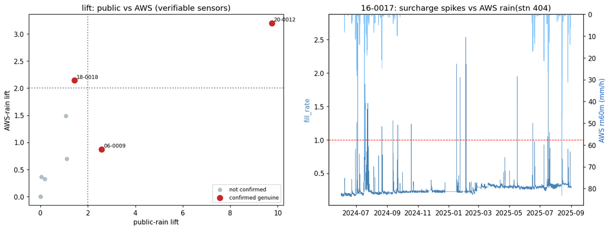

그림 16. AWS 1분 강우 재검증. (좌) 공공강우 lift vs AWS강우 lift — 둘 중 하나라도 ≥2이고 강우동반·non-stuck이면 확정(빨강). (우) 신규확정 16-0017: 평소 fill 0.24인 건강한 센서가 호우(파란막대, 위가 강함) 때만 fill≥1로 치솟음 = 강우성 만관.

| 센서 | 최종판정 | surch(전체) | AWS커버내 | 강우동반 | 공공 lift | AWS lift |
| --- | --- | --- | --- | --- | --- | --- |
| 20-0012 | 확정(공공+AWS) | 2861 | 116 | 1.00 | 9.75 | 3.20 |
| 16-0017 | 확정(AWS신규) | 307 | 265 | 0.72 | — | 2.31 |
| 18-0018 | 확정(AWS신규) | 1533 | 94 | 0.98 | 1.43 | 2.14 |
| 11-0004 | 확정(공공·AWS박함12건) | 922 | 12 | 1.00 | 2.08 | 3.30 |
| 06-0009 | 확정(공공·AWS원거리2.1km) | 896 | 896 | 0.28 | 2.58 | 0.87 |

**결과**: 진짜 강우성 만관 **공공 3 → AWS로 16-0017·18-0018 신규 추가(확정 5)**. **20-0012가 공공·AWS 양쪽 확정으로 최강**. 16-0017은 평소 fill 0.24인 멀쩡한 센서가 호우 때만 만관 = 교과서적 강우성 surcharge.

**한계**: AWS 검증가능 센서는 **16개뿐**(나머지는 surcharge가 2022년=AWS커버 밖이거나 stuck). 미검증 79는 대체로 여전히 미검증(자료 한계). 06-0009는 공공 lift 2.58이나 최근접 AWS가 2.1km라 0.87 — 거리탓 가능, 보류. 다음: **확정 만관센서 ↔ 도로 침수지점 시공간 동조**로 강우→만관→침수 사슬 마무리.

### 다음 단계

- ① 확정 만관 센서(3 + AWS 재검증 추가분)가 **도로 침수 지점(확정 6/co-located)과 시공간 동조**하는지 → *강우 → 만관 → 침수* 사슬 완성.
- ② **22/23구역 capacity 재교정**(fill 중앙값>1인 35센서).
- ③ AWS 강우 나머지 여름 다운로드 완료(2024 잔여 + 2025) → 비강우 모호·미검증 재검증.

## 8. 강우 → 하수 만관 → 도로 침수 사슬 검증 (2026-06-24)

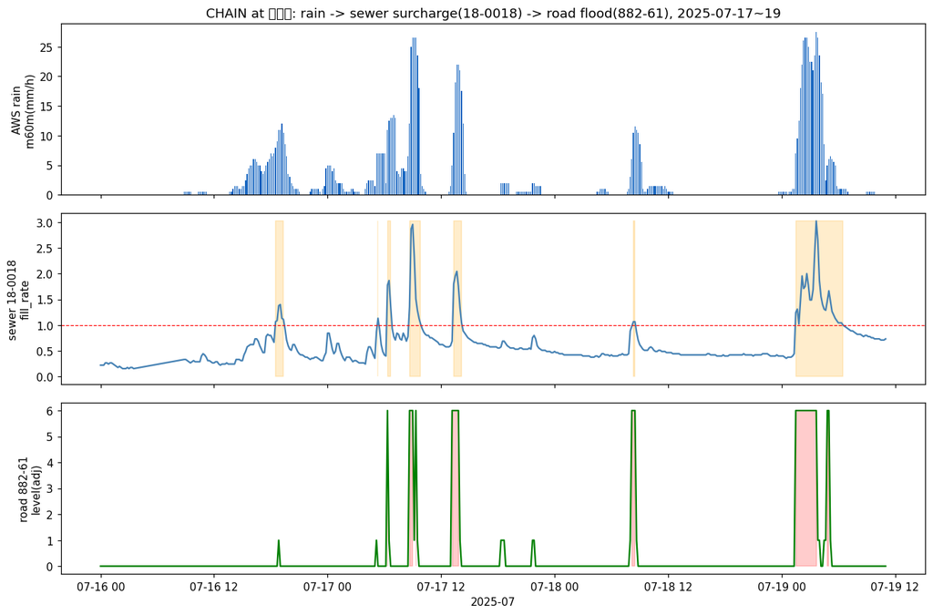

그림 17. 시흥동 사슬(2025-07-17~19 호우). 위=AWS 강우, 가운데=하수 18-0018 fill_rate(주황=만관구간), 아래=도로 882-61 수위(빨강=침수). 강우 폭발마다 하수가 만관을 돌파하고 도로가 침수 — 강우→만관→침수가 함께 반응.

| 시흥동 쌍 시간 동조 (공통기간 2025-07-11~08-31, 약 7주) |  |
| --- | --- |
| 만관 시점 강우 동반 | 100% |
| 도로침수 시점 직전 6h내 만관 동반 | 95% |
| 도로침수 시점 강우 동반 | 100% |
| 만관↔도로침수 교차상관(최대) | 0.60 (lag ~0, 거의 동시) |

**결과**: 시흥동에서 **강우→만관→침수 사슬이 또렷**. 도로침수의 95%가 직전 6h 내 하수 만관을 동반하고, 강우는 양쪽 모두 100% 동반. 사용자 가설(침수=하수 만관 원인)을 **강하게 지지**하는 첫 co-located 증거.

**한계(과장 금지)**: ①겹치는 기간이 **약 7주(2025 여름)** 뿐(도로센서가 2025-07-11부터). ②만관·침수가 **거의 동시**(±10~20분)라 10분 해상도로는 *만관이 침수의 원인*인지 *같은 호우가 둘 다 유발*(공통원인)인지 단정 불가. ③co-located 검증 가능 쌍이 **사실상 1개**. 다음: 18-0018 1분 원자료로 분단위 선후 분리, 차순위 쌍(11-0004↔월계동9-2 등) 점검.

## 9. GNN 학습셋 가용성 진단 — 현재 데이터로는 구축 불가 (2026-06-24)

**원 목표는 관악구 배수지역 침수예측 GNN**(관악 데이터 부족 → 서울 확장). 지금 데이터로 GNN 학습셋이 가능한지 냉정히 진단했다.

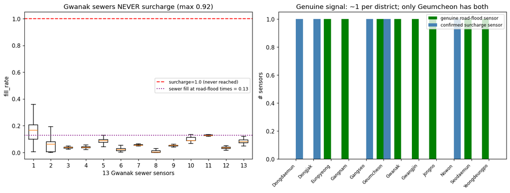

그림 18. (좌) 관악 하수 13센서는 호우에도 fill 1.0(만관)에 절대 도달 못함(최대 0.92); 도로 침수 시각에도 하수는 0.13만 참 = 관악 침수≠하수만관. (우) 진짜 신호가 구마다 1개씩 흩어지고 도로·하수가 공존하는 곳은 금천(시흥동) 1곳뿐.

**판정: 현재 센서 데이터로 GNN 침수예측 학습셋은 구축 불가.**

1. **관악 단독 불가**: 진짜 침수센서 1개(조원로5-6), 하수 만관 **0건**. 도로 침수 시각에도 하수 fill 0.13 → **관악 침수는 하수 만관과 무관**(빗물이 관에 차기 전 저지대 도로에 고이는 표면류형 추정).
2. **서울로 넓혀도 GNN 부적합**: 진짜 신호가 구마다 1개씩 흩어지고(도로·하수 공존=금천 1곳), 도로↔하수 결합 0.05 → GNN 핵심인 **공간 전파를 학습할 dense subgraph 부재**. 도로 진짜 양성 0.42%·양성 센서의 93%가 아티팩트형.
3. 유일한 dense 사슬은 **시흥동 1쌍** → 단일/소수지점 모델은 가능하나 그래프 모델은 표본 부족.

**GNN을 살릴 대안 경로**: 희소한 *도로침수 라벨* 대신 **하수 관망에서 수위·만관을 예측하는 GNN**이 현실적 — 484노드·연속수위(78% A등급)·실제 관 토폴로지·강우구동(corr 0.21). 단 **관 흐름방향 토폴로지(관망 GIS)**가 있어야 엣지가 물리적이 된다(현재 엣지는 근접·배수구역 기반).

| 필요 데이터 | 현재 병목(증거) | 구체 소스 | 우선순위 |
| --- | --- | --- | --- |
| **① 독립 침수 정답** | 양성 센서의 93%가 아티팩트형·진짜 양성 0.42% | 서울시 침수흔적도 GIS, 120/119 침수신고, 침수 CCTV, 재해연보 | 최우선 |
| **② 다년 침수 이력** | 진짜양성 ~1549bin·소수 호우일; 도로센서 2024~만 | 2020·2022 대홍수 포함 다년 여름 수위·침수기록 | 최우선 |
| **③ 관망 토폴로지 GIS** | 엣지가 근접기반(흐름방향X), 하수GNN 물리근거 없음 | 우수/오수 관거 노드-엣지(흐름방향), 배수구역 경계 | 높음(하수GNN 핵심) |
| **④ 저지대 DEM·우수유입구** | 관악=표면류형 추정(하수 안참) | 수치표고(DEM), 빗물받이/유입구 위치 | 중간 |
| **⑤ 레이더 강우** | AWS 1.5km 공백, 국지호우 누락 | 기상청 레이더 강우(HSR) 또는 조밀 AWS | 중간 |

## 10. 제원표 배수구역 기반 하수↔도로 교차 매칭 (2026-06-24)

거리 대신 **공식 제원표의 배수구역**(같은 하수 배수단위)으로 만관 하수↔침수 도로를 짝지어 시흥동 외 추가 사슬을 찾았다. (전제: 제원표 배수구역=정제 노드 배수구역 100% 일치, 관규격도 100% 일치 → 제원표가 우리 작업의 원천임을 확인.)

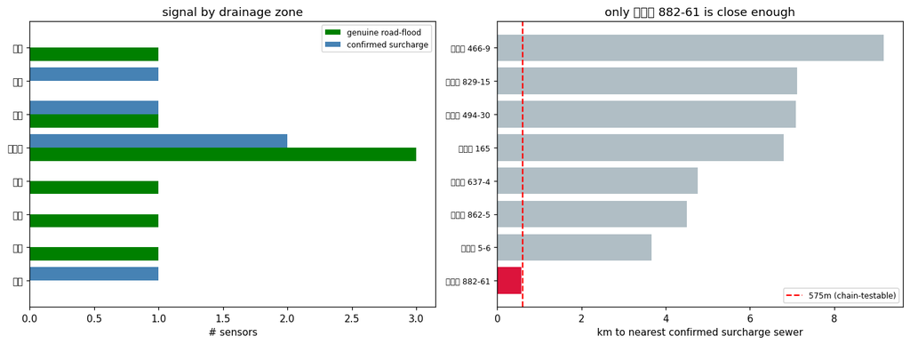

그림 19. 제원표 배수구역 기반 매칭. (좌) 배수구역별 진짜상습 도로(녹)·확정만관 하수(청); 안양천만 둘이 다수 공존. (우) 진짜상습 도로 10곳→최근접 확정만관 거리; 575m선(빨강) 안쪽은 시흥동 882-61 단 1곳, 나머지 3.6~9.2km.

**결과**: 배수구역 매칭으로도 **시흥동(안양천, 575m) 외 새 사슬 쌍은 없음**. 진짜상습 도로 10곳 중 확정만관 하수와 575m 이내는 시흥동 882-61 단 1곳, 나머지 3.6~9.2km.

**왜**: 공식 배수구역이 **15개 거대 basin**으로 너무 coarse(안양천 하나에 하수 98·도로 35센서). 같은 구역이어도 수 km 떨어진 다른 소배수구역 → GNN 엣지/페어링 단위로 부적합, **소배수구역(세부 관망) 토폴로지 필요**.  
**부수 발견**: 마포·반포·불광·홍제는 진짜상습 도로 침수가 있으나 **확정만관 하수 0** = 하수 만관 없이 침수(표면류형). 관악 결론과 일치 — *침수≠하수만관*인 지역이 다수.

## 11. 03_GIS 관망 데이터 — 토폴로지 병목(③) 거의 해소 (2026-06-24)

앞서 GNN의 핵심 병목으로 지목한 **관 흐름방향 토폴로지·소배수구역**이, `03_GIS`의 **관악구 하수관로 GIS**에 이미 들어 있음을 확인.

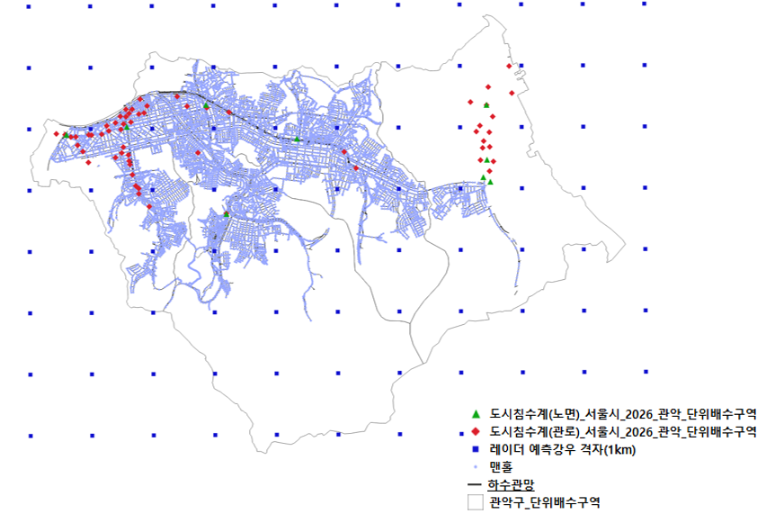

그림 20. 관악구 GIS — 하수관망(파란 선)·맨홀·수위계(빨강=관로, 녹색=노면)·레이더 강우격자(1km). 관망에 시·종점 맨홀과 관저고가 있어 흐름방향 유향 그래프 구성 가능.

| GIS 자산(관악구) | 내용 | 완전성 |
| --- | --- | --- |
| 하수관로(유향 엣지) | 시점맨홀→종점맨홀 17,286관 | 92.9%(16,059관) 엣지화 가능 |
| 관저고(흐름방향) | 시·종점 관저고로 중력방향 판정 | 92.4% |
| 소배수구역 | **40개**(봉천01-11·신림02-03·대림-02…) | 100% (거대 15basin→세분) |
| 맨홀(노드) | 12,184개(지반고 hsl 포함) | — |
| 물받이/토구 | 물받이 27,447·토구 137(하천유입 ifw_riv) | 표면유입(④)·하천역류 후보 |
| 레이더 강우격자 | 1km HFC 격자(⑤) | AWS 1.5km 공백 보완 |

**의미**: 필요데이터 **③(관망 토폴로지)·④(빗물받이)·⑤(레이더강우)가 관악구에 대해 이미 확보**. 이제 맨홀=노드, 유향 관거=엣지, 소배수구역=집계단위로 **GNN 그래프 뼈대를 즉시 구성 가능**. 깨끗한 하수 수위(연속값)를 타깃으로 한 **관악 하수 수위 예측 GNN**은 라벨 없이도 착수 가능.

**그래도 남는 두 한계**: ① GIS는 **관악구 전용** — 시흥동 등 확정 사슬쌍 미포함. ② **학습 라벨/사건 희소(①②)는 그대로** — 관악 진짜 도로침수 1센서·하수 만관 0. GIS는 '그래프 구조'를 주지만 '무엇을 침수로 학습시킬지' 정답은 주지 않음. → 결합 제약이 **토폴로지 부재 → 독립 침수정답·다년사건 부재**로 이동.

## 12. CSI 베이스라인 — 고객 핵심지표 점검 (2026-06-24)

고객이 **CSI(Critical Success Index)=TP/(TP+FP+FN)**를 최우선으로 지목. GNN 진행 전 베이스라인 CSI를 점검. 관악은 만관(fill≥1) 0건·근접만관(0.8) 3건뿐이라 CSI는 **고수위 fill≥0.5·0.6**로 정의(도로 침수 CSI는 라벨 부재로 미산출 — 본 CSI는 하수 고수위 탐지 대리지표).

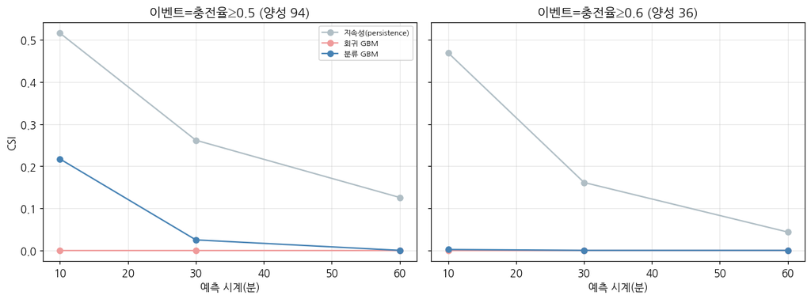

그림 21. CSI 베이스라인(관악 17센서, test 2025-05~08). 이벤트=하수 고수위 fill≥0.5/0.6. persistence(회색)가 모든 호라이즌에서 학습모델을 압도. 회귀 GBM은 CSI≈0(극단 미예측), 분류 GBM도 persistence 미달(오경보 과다).

| 이벤트 | 모델 | +10분 | +30분 | +60분 |
| --- | --- | --- | --- | --- |
| fill≥0.5 (양성 94) | persistence | 0.516 | 0.262 | 0.126 |
|  | 분류 GBM(강우+이력) | 0.217 | 0.025 | 0.000 |
|  | 회귀 GBM | 0.000 | 0.000 | 0.000 |
| fill≥0.6 (양성 36) | persistence | 0.469 | 0.161 | 0.043 |
|  | 분류/회귀 GBM | ≤0.002 | 0.000 | 0.000 |

**핵심 발견 (진행 전 필독)**:

1. **회귀(MAE/RMSE 최적)는 CSI≈0** — 희소 극단을 임계 위로 안 올림. **CSI엔 분류 모델 필수.**
2. **그래도 persistence가 CSI를 지배**(0.52→0.13). 분류 GBM조차 오경보 과다로 미달. 관악 고수위는 **강우성 급변이 아니라 느린 기저상태**라 강우·이력이 직전값을 못 이김.
3. 모델이 비빌 구간은 **30~60분**(persistence CSI 0.04~0.26)이나 학습모델이 거기서도 실패.

**의미**: GNN이 정당화되려면 **CSI에서 persistence(특히 30~60분)를 넘어야** 함. 관악엔 강우→급변 신호가 약해 어려울 수 있음 → CSI의 실질 가치는 **실제 만관 발생지역(시흥동류) + 침수 라벨** 확보가 전제. 본 베이스라인이 GNN의 공식 CSI 바.

## 13. 하수 수위 GNN Phase 1 — 관악 GIS 유향 그래프 (2026-06-24)

관악 GIS 관거(시점맨홀→종점맨홀, 중력 흐름방향 92%)로 **유향 그래프**(노드 13,272·엣지 15,217) 구성, 17 수위센서를 관거에 snap(중앙 1m).

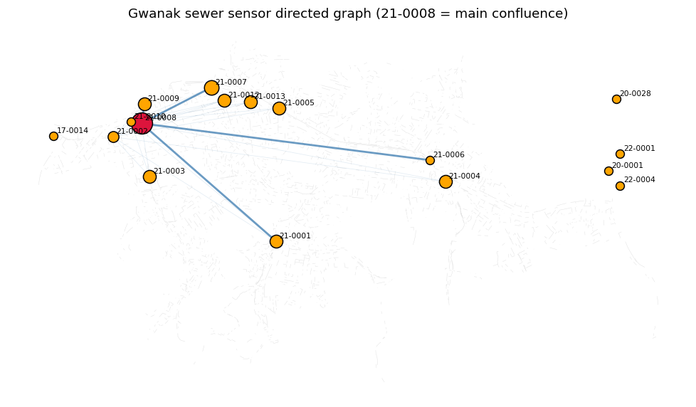

그림 22. 관악 하수센서 유향 그래프. GIS 관거(시점→종점맨홀, 중력방향 92%)로 구성. 21-0008(빨강)이 8개 상류 센서가 모이는 하류 합류점(21-0001 1홉·21-0006/21-0007 4홉 등). 우측 안양천 트렁크 4센서는 고립.

**실질 구조 확인**: `21-0008`이 **8개 상류 센서가 모이는 하류 합류점**(21-0001 1홉·21-0009 3홉·21-0006/21-0007 4홉…). GNN이 *상류→하류 조기경보*를 학습할 구조가 존재. → Phase 2에서 상류 정보가 CSI를 높이는지 시험.

20-0001·20-0028·22-0001·22-0004는 안양천 트렁크(박스암거)라 동일 노드로 snap(충돌)·고립 — 상류 전파 대상 아님.

## 15. 서울 전역 위험수위 재조사 — 만관→위험수위 재정의 (2026-06-24)

침수는 하수관 만관(fill≥1)에서만 나는 게 아니라 **위험수위(관 80%↑ 충전, 통수능력 저하)**에서도 발생. 만관 기준이 신호를 가렸을 수 있어 **fill≥0.8**로 서울 전역 강우성 진위감사를 재실행.

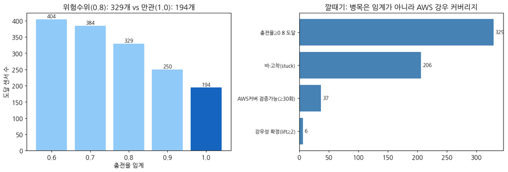

그림 24. 서울 전역 위험수위 재조사. (좌) fill 임계별 도달 센서수 — 위험수위(0.8) 329 vs 만관(1.0) 194. (우) 깔때기: 도달 329→비stuck 206→AWS커버 검증가능(n_cov≥30) 37→강우성 확정 6. 병목은 임계가 아니라 AWS 강우 커버리지.

| 단계(fill≥0.8) | 센서수 |
| --- | --- |
| 위험수위 도달 | 329 (만관 194의 1.7배) |
| 비-stuck (천장/구간 제외) | 206 |
| AWS커버 검증가능(위험사건 n_cov≥30) | 37 |
| 강우성 확정(lift≥2 & 강우동반≥0.5) | 6 |

**사용자 지적 입증**: 위험수위로 보면 **도달 센서 194→329(1.7배)**. 만관은 안 가도 위험수위까진 차는 센서가 많음 = 만관 기준이 신호를 가렸음. 위험사건은 (관악 확인상) 100% 강우동반·90%+ 여름.

**그러나 강우 검증된 진짜 위험센서는 6개**(만관 5와 비슷): 01-0005·02-0001·10-0008·15-0006(신규 4)·16-0017·18-0018. **병목은 임계가 아니라 ①AWS 강우 커버(2024-06~)라 검증가능 위험사건 30+ 센서가 37개뿐 ②stuck 오염 123센서.** 진짜 6 중 진짜상습 도로와 575m 이내는 **여전히 18-0018(시흥동) 1곳뿐**(나머지 3.3~10.3km). → 사슬 검증쌍은 시흥동 유지.

**해법**: **AWS 강우 잔여분/레이더로 커버 확대**하면 미검증 188(대부분 n_cov<30) 중 상당수 검증 가능 → 위험수위 학습셋 대폭 확대 여지. = 필요데이터 ⑤(레이더강우) 우선순위 상승.

## 16. A-1: 서울 전역 위험수위 예측 CSI + B(데이터 확보) 준비물 (2026-06-24)

관악(사건 없음)이 아니라 **실제 위험수위(충전율≥0.8)에 도달하는 서울 전역 센서**에서, 강우+이력 모델이 persistence를 CSI로 넘는지 시험. (test 2025-05~09, 분류 GBM·train에서 CSI최대 임계)

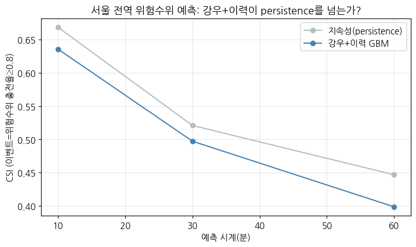

그림 25. 서울 전역 위험수위(충전율≥0.8) 예측 CSI. 실제 위험수위 도달 센서 대상. persistence(회색)가 강우+이력 GBM(파랑)을 모든 호라이즌에서 근소하게 앞섬 — 강우가 수위와 거의 동시 반응해 리드타임 없음.

| 예측시계 | persistence CSI | 강우+이력 GBM CSI |
| --- | --- | --- |
| +10분 | 0.668 | 0.636 |
| +30분 | 0.521 | 0.497 |
| +60분 | 0.447 | 0.399 |

**두 가지가 동시에 사실**: ①**위험수위는 예측 가능**(CSI 0.45~0.67, 관악·도로라벨보다 훨씬 높고 60분에도 유지). ②**그러나 persistence를 못 넘음**(GBM은 POD↑이나 FAR↑로 순 CSI 낮음). 관악보다 격차는 좁혀졌으나 역전 없음.

**결론**: 현재 데이터(국지 강우+자기 이력)로는 어떤 모델도 CSI에서 persistence를 못 넘음 — **강우가 수위와 거의 동시 반응해 리드타임이 없기 때문**. 모델이 이기려면 ①**수위를 앞서는 강우 입력=레이더(접근 호우)** 또는 ②**진짜 침수 타깃=침수 라벨** 필요. → A(현 데이터 모델링) 한계 확정, **B(데이터 확보)가 정답.**

### B 준비물 (우선순위순)

| # | 준비물 | 출처 | 용도 |
| --- | --- | --- | --- |
| 1 | 레이더 강우(HSR/HFC 격자) | 기상청 기상자료개방포털·API허브 (03_GIS에 1km 격자 shp 보유) | 수위를 앞서는 공간·이동 강우 → 리드 + 미검증 188 검증 |
| 2 | 침수 정답 라벨 | 서울시 침수흔적도·120/119·재해연보·CCTV | 실제 침수 supervised 타깃(현재 1지점) |
| 3 | 하천 수위 | 한강홍수통제소(hrfco) — 도림천·안양천 | 관악 하천역류 침수 검증·입력 |
| 4 | DEM(수치표고) | 국토정보플랫폼 (빗물받이는 03_GIS 보유) | 저지대 표면류 그래프·위험저지대 |
| 5 | 다년 침수 사건 | 2020·2022 대홍수 포함 과거 기록 | 현 센서 2024~만 → 다년 학습 |

**핵심 2개**: 레이더 강우(1)=리드타임 문제 직접 해법·격자 보유로 즉시 연동; 침수 라벨(2)=모든 supervised 예측의 전제.

## 17. A-1 심화: 위험수위 진입(onset) 조기예측 CSI (2026-06-24)

A-1 전체 CSI는 대부분 '위험 유지' 구간이라 persistence가 강했다. 실무 가치는 '곧 진입'(onset). **현재 비위험(충전율<0.8) 시점만** 추려 h분 뒤 위험 진입 예측을 평가.

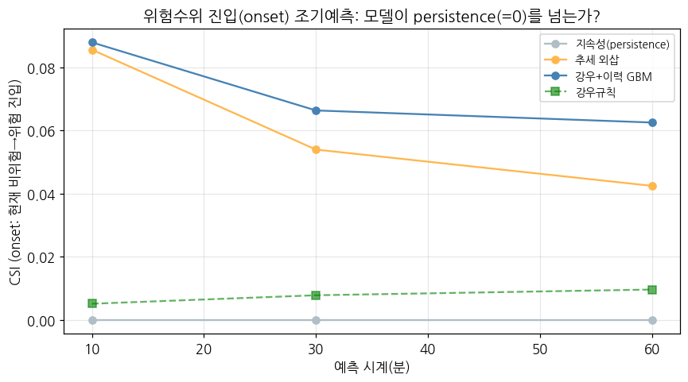

그림 26. 위험수위 진입(onset) 조기예측 CSI. 현재 비위험(충전율<0.8) 시점만 평가. persistence는 구조적으로 0. 강우+이력 GBM(파랑)이 0을 넘으나 CSI≤0.09(진입의 10%만 포착, 오경보 80%).

| 예측시계 | persistence | 추세 외삽 | 강우규칙 | 강우+이력 GBM |
| --- | --- | --- | --- | --- |
| +10분 | 0.000 | 0.086 | 0.005 | 0.088 |
| +30분 | 0.000 | 0.054 | 0.008 | 0.066 |
| +60분 | 0.000 | 0.042 | 0.010 | 0.062 |

**①조기경보 신호 존재**: persistence는 onset에서 구조적으로 CSI=0인데 모델은 0을 넘음(0.06~0.09) — A-1 전체 CSI가 가렸던 부분. 현 데이터로도 약간의 조기경보 능력 있음.

**②그러나 실무 수준 미달**: CSI≤0.09, 진입의 10%만 포착·오경보 80%. 모델은 단순 추세 외삽과 비슷, 국지 강우규칙은 무용(FAR 0.99). 이유=진입은 호우 강도·타이밍 의존인데 **국지(점) 강우는 거의 동시반응이라 '다가오는 호우'를 못 봄**.

**→ 레이더 정당화 + 기준선**: 의미있는 조기경보는 공간·이동 정보를 담은 **레이더 강우** 필요. **현 onset CSI 0.06~0.09 = 내일 레이더가 넘어야 할 기준선.**

## 18. 관악 하천역류 가설 검증 — 기각 (2026-06-24)

사용자 정보(관악 침수=하천역류·땅꺼짐)를 검증. 한강홍수통제소 hrfco에서 **관악 도림천 수위계 2개소(신림5교·신대방1교)** 전 기간(2024-06~2025-09) 확보 → 조원로 5-6 침수 시각에 도림천이 고수위인지 검사.

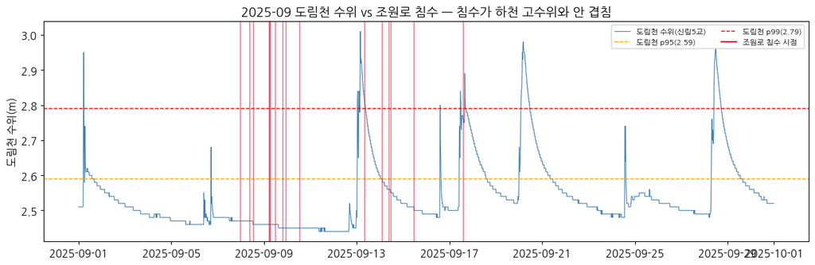

그림 27. 도림천 수위(신림5교) vs 조원로 침수(2025-09). 빨간 선=침수 시점. 침수 대부분이 도림천 평상시(~2.45m)에 발생, 하천 피크(p95/p99)와 안 겹침 → 하천역류 기각.

| 조원로 침수 30회 | 도림천 wl >p95 | >p99 |
| --- | --- | --- |
| 순간값 | 7% | 3% |
| ±6h 창 최대 | 10% | 7% |

**하천역류 기각**: 조원로 침수의 **90%가 도림천 평상시 수위**(±6h로도). 도림천은 폭우에 반응하나(반응폭 1.2m, 고수위 7~9월 집중) **침수와 사건단위 동조 안 함**. 9월 동시 다발=같은 폭우철일 뿐.

**소거법 결론**: 관악 침수 ≠ 하수 만관, ≠ 도림천 하천역류 → **국지 호우 표면류(pluvial surface flooding)** 또는 일부 센서 아티팩트(겨울 6건 의심). → **국지 강우강도(레이더)로 확인 필요**. 땅꺼짐은 수문 데이터 범위 밖(별도).

## 19. Phase 3: 실제 시공간 GNN — 관악 하수 위험수위 예측 (2026-06-24)

Phase 1(유향 그래프)·Phase 2(상류 피처 근사) 다음, **진짜 GNN 모델** 구축: 노드별 GRU(시간) + 유향 GraphSAGE(상류→하류 전파) + 헤드, torch+GPU. 타깃=위험수위(충전율≥0.5; 관악은 0.8 거의 없음). **그래프 ON/OFF ablation**, 시드3 평균.

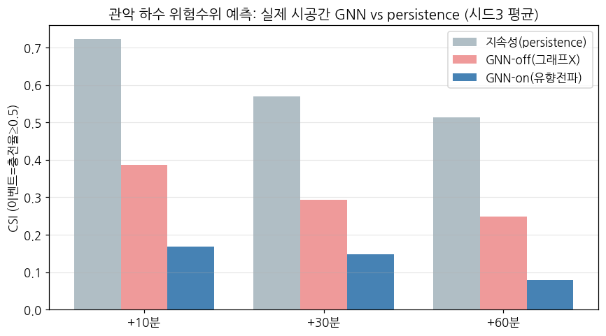

그림 28. Phase 3 실제 시공간 GNN(관악 17센서, 위험수위 충전율≥0.5, 시드3평균). persistence(회색)가 GNN-off(분홍)·GNN-on(파랑)을 모두 압도. 유향전파(on)가 그래프없음(off)보다도 낮음=토폴로지가 노이즈만 추가.

| 예측시계 | persistence | GNN-off(그래프X) | GNN-on(유향전파) |
| --- | --- | --- | --- |
| +10분 | 0.723 | 0.387 | 0.169 |
| +30분 | 0.570 | 0.293 | 0.148 |
| +60분 | 0.512 | 0.248 | 0.078 |

**실제 GNN도 persistence를 못 넘음**(모든 호라이즌 지배). 게다가 **그래프(on)가 그래프없음(off)보다 일관되게 더 나쁨** — 관악엔 전파할 신호가 없어 유향 전파가 각 노드 자기신호를 이웃 노이즈로 희석. Phase 2 근사 결과를 **실제 GNN이 재확인**.

**= 모델 한계 아닌 데이터 한계**(관악 위험수위는 강우성 급변 아닌 느린 기저상태). 단 **파이프라인 완성**: 노드 입력에 레이더 강우를 꽂으면 즉시 재측정 가능(POC 하네스 + KICT 납품용 "관망 토폴로지 시공간 GNN 작동" 데모).

[figure not shown]

[output not shown]

**관악 GNN 라인 결론**: Phase 0~2 측정 결과, **관악 데이터로는 CSI에서 persistence를 넘는 모델(GNN 포함) 불가**. GIS 관망 그래프(21-0008 합류점 등 구조)는 실재하나 전파시킬 사건(만관/침수)이 없음. CSI가 의미를 가지려면 **실제 만관 발생지역(시흥동류) + 침수 라벨(필요데이터 ①②)**가 전제.

## 결론 & 다음 단계

- ✅ 정제·상관·nowcast·라벨 진위감사·surcharge 진위감사·AWS 재검증·시흥동 사슬·배수구역 매칭·GNN 가용성·GIS 관망 점검 완료.
- 🔑 핵심: **현재 데이터로 침수예측 supervised 학습 불가**(라벨 양성센서 93% 아티팩트형·진짜신호 희소·관악 침수≠하수만관). 단 **03_GIS로 관악 관망 토폴로지(③④⑤) 확보** → 병목이 **토폴로지 부재 → 독립 침수정답·다년사건(①②) 부재**로 이동.
- 🔴 측정 완료: **위험수위(fill≥0.8) 재정의**로 도달센서 194→329, 그러나 **서울 전역에서도 강우+이력 모델이 CSI로 persistence를 못 넘음**(리드타임 부재). → 현 데이터 모델링 한계 확정.
- 🟢 다음(B-데이터 확보): **①레이더 강우**(리드타임·미검증 검증) **②침수 라벨**(침수흔적도/120·119) ③하천 수위 ④DEM. 준비물·출처는 §16.
- 🟡 병행: ①② 독립 침수정답(침수흔적도·120/119)·다년 사건 확보 가능성 점검.
- ⏸ 도로 침수 supervised 예측·겨울 시즌은 라벨 확보 전까지 보류.

※ 본 보고서의 모든 그림은 노트북(`correlation_road_sewer`, `nowcast_baseline`, `label_quality_audit`, `recurrent_flood_report`)에서 실제 실행으로 생성된 것이다.